# Taller: SparkR (R on Spark) I

VII JORNADAS DE USUARIOS DE R

Salamanca, 5 de noviembre de 2015 Jorge Ayuso Rejas

# Introducción

## ¿Qué es *Spark*?

[figure not shown]

> “Apache Spark™ is a fast and general engine for large-scale data processing.”

## ¿Por qué Spark? ¿Qué ventajas tiene? Mi resumen

Hadoop nació (~2005) para procesar grandes cantidades de datos en paralelo. Poco a poco han surgido nuevas problemáticas que no se podían resolver con el paradigma *MapReduce* y han ido surgiendo nuevos programas para solventar estas problemáticas, creando así nuevos sistemas especializados:

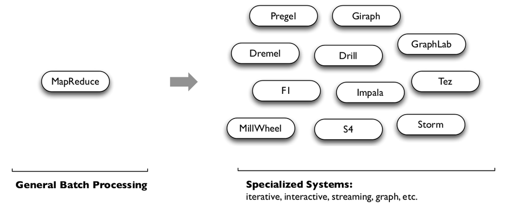

Spark es uno de estos nuevos sistemas, cambia la manera de trabajar internamente (utiliza memoria, *RDD*,*DAG*…) y unifica bajo un solo proyecto los grandes problemas de datos hasta el momento: Procesamiento en Batch, en *streaming*, *machine learning*, *SQL*…

Además incluye en el mismo proyecto varios lenguajes: Scala, Java, python y R.

### **¡NO SOLO JAVA!**

[figure not shown]

Spark se ha hecho famoso y todo el *BigData* mira hacia él. Esto ha hecho que muchas de las aplicaciones ya existentes se hayan hecho compatibles con Spark y que estén surgiendo nuevas enfocadas en trabajar con Spark. Pero además Spark es compatible con Hadoop así que podemos usar el mismo cluster y los mismos datos con uno u otro.

[figure not shown]

Más información:

- http://www.slideshare.net/pacoid/crash-introduction-to-apache-spark
- http://es.slideshare.net/arjones/introduccion-a-apache-spark

## Descargamos Spark:

Web: https://spark.apache.org/downloads.html  
Precompilado y compatible con Hadoop 2.6: http://www.apache.org/dyn/closer.lua/spark/spark-1.5.1/spark-1.5.1-bin-hadoop2.6.tgz

# SparkR: Usando Spark desde R

SparkR es muy nuevo (junio 2015 en el proyecto oficial), por ahora solo es compatible con la *DataFrame API*. Esto significa que hoy por hoy solo podemos trabajar con datos estructurados (tipo `dplyr`) y no se puede paralelizar código en R (R no hace falta que esté instalado en todos los nodos).  
Lo bueno: Al entrar a formar parte del proyecto su evolución está garantizada. Para la versión 1.6 se esperan muchas novedades.

Más información:

- https://spark.apache.org/docs/latest/sparkr.html
- https://spark.apache.org/docs/latest/api/R/index.html

## Primeros pasos con SparkR

Veamos algunos ejemplos usando SparkR en local (solo necesitamos tener R y Java instalado). Descargamos y configuramos para poder usar el paquete de R, seguimos los siguientes pasos:

1. Descargamos Spark (links arriba)
2. Descomprimimos el archivo descargado
3. Introducimos en el archivo `.Renviron` lo siguiente:

> `SPARK_HOME = <Directorio donde hemos descomprimido spark>`
4. (Recomendable): En la carpeta `$SPARK_HOME/conf` copiar `log4j.properties.template` a `log4j.properties` y cambiar la siguiente línea:

> `log4j.rootCategory=INFO, console`

por

> `log4j.rootCategory=ERROR, console`

Iniciamos R y comprobamos que la variable de entorno está bien configurada:

```r
Sys.getenv("SPARK_HOME")
```

```
## [1] "./spark-1.5.1-bin-hadoop2.6/"
```

Añadimos la librería de *SparkR* al `libPath` y cargamos la librería:

```r
.libPaths(c(file.path(Sys.getenv("SPARK_HOME"),"R/lib/"),.libPaths()))
library(SparkR)
library(magrittr)
```

También vamos a usar la librería `magrittr` para usar `%>%` para programar.

Arrancamos Spark, esto lo hacemos creando un *Spark Context* en la variable `sc`. En nuestro caso indicamos que queremos arrancar Spark de manera local y con todos los núcleos disponibles.

```r
sc <- sparkR.init(master = "local[*]",appName = "Primera Prueba")
```

```
## Launching java with spark-submit command ./spark-1.5.1-bin-hadoop2.6//bin/spark-submit   sparkr-shell /tmp/Rtmpj4ePcb/backend_port1cfb24e0f061
```

Una vez arrancado Spark, podemos ver la *Spark UI* en http://localhost:4040:

[figure not shown]

Inicializamos el `sqlContext` para poder hacer uso de la `DataFrame API`

```r
sqlContext <- sc %>% sparkRSQL.init()
```

Podemos crear un `DataFrame` de Spark desde un `data.frame` local:

```r
class(iris)
```

```
## [1] "data.frame"
```

```r
df_iris <- sqlContext %>% createDataFrame(iris)
class(df_iris)
```

```
## [1] "DataFrame"
## attr(,"package")
## [1] "SparkR"
```

```r
df_iris
```

```
## DataFrame[Sepal_Length:double, Sepal_Width:double, Petal_Length:double, Petal_Width:double, Species:string]
```

```r
df_iris %>% head
```

```
##   Sepal_Length Sepal_Width Petal_Length Petal_Width Species
## 1          5.1         3.5          1.4         0.2  setosa
## 2          4.9         3.0          1.4         0.2  setosa
## 3          4.7         3.2          1.3         0.2  setosa
## 4          4.6         3.1          1.5         0.2  setosa
## 5          5.0         3.6          1.4         0.2  setosa
## 6          5.4         3.9          1.7         0.4  setosa
```

La diferencia entre un `DataFrame` de Spark es que no vive en la memoria de R. Si no en Spark así que podremos trabajar con grandes *datasets* de manera cómoda, por ejemplo:

```r
df_iris %>% filter("Sepal_Length>7") %>% count
```

```
## [1] 12
```

También podemos registrar el `DataFrame` y usar SQL:

```r
df_iris %>% registerTempTable("iris")
sqlContext %>% tables %>% collect
```

```
##   tableName isTemporary
## 1      iris        TRUE
```

```r
sqlContext %>% sql("select count(*) from iris where Sepal_Length>7") %>% collect
```

```
##   _c0
## 1  12
```

Cuando hemos terminado cerramos Spark:

```r
sparkR.stop()
```

Este obra está bajo una [licencia de Creative Commons Reconocimiento-CompartirIgual 4.0 Internacional](http://creativecommons.org/licenses/by-sa/4.0/).